# Multilevel Modelling Practical 7

## Instructions - start here!

**Exercise 1** involves the analysis of the data set used in Example 2 of the week 7 lecture. **Exercise 2** considers the data set on survival times from Example 3. This lab is deliberately shorter than previous labs to allow time to work on the summative assessment.

## Exercise 1 (Aids data: Example 2 from lecture 7)

Read in and visualize the data:

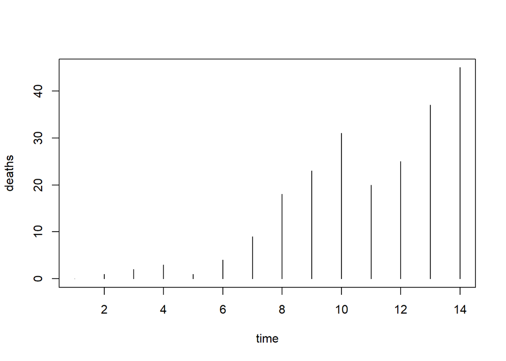

```r
aids <- read.table("https://andygolightly.github.io/teaching/MATH43515/aids.asc", header = TRUE)
plot(aids, type="h")
```

Fit a Poisson GLM and display the model summary:

```r
glm2 <- glm(deaths~time, family=poisson(link=log), data=aids)
summary(glm2)
```

```
##
## Call:
## glm(formula = deaths ~ time, family = poisson(link = log), data = aids)
##
## Deviance Residuals:
##      Min        1Q    Median        3Q       Max
## -2.21008  -1.02032  -0.69704   0.04028   2.70758
##
## Coefficients:
##             Estimate Std. Error z value Pr(>|z|)
## (Intercept)  0.33963    0.25119   1.352    0.176
## time         0.25652    0.02204  11.639   <2e-16 ***
## ---
## Signif. codes:  0 '***' 0.001 '**' 0.01 '*' 0.05 '.' 0.1 ' ' 1
##
## (Dispersion parameter for poisson family taken to be 1)
##
##     Null deviance: 207.272  on 13  degrees of freedom
## Residual deviance:  29.654  on 12  degrees of freedom
## AIC: 86.581
##
## Number of Fisher Scoring iterations: 5
```

Add the fitted curve (expected number of aids cases as a function of time) to the plot with:

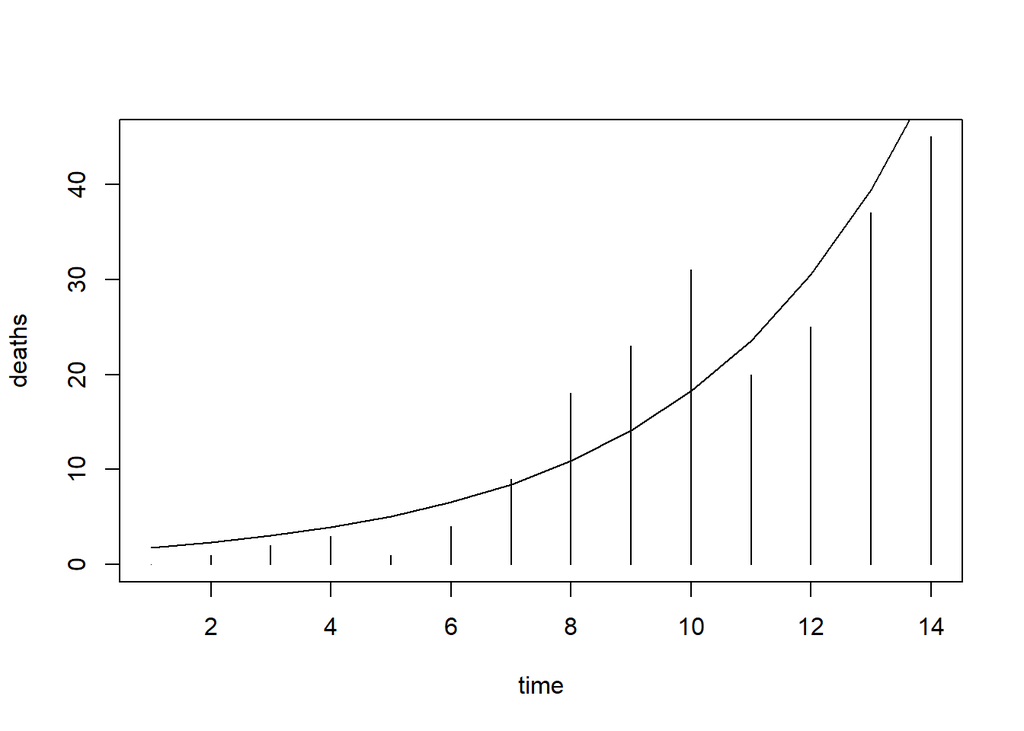

```r
plot(aids, type="h")
lines(aids$time, predict(glm2, type="response"))
```

**TASK:** Reproduce this plot using `ggplot`. Hint: this will require `geom_segment()`.

**TASK:** What would be the predicted number of deaths in month 15?

There are three ways of answering this question:

- Manually, by implementing $\exp(\hat{\beta}_0+\hat{\beta}_1\times 15)$;
- Using function `predict` to obtain $\hat{\beta}_0+\hat{\beta}_1\times 15$, but still exponentiating the outpout;
- Using function `predict` with option `type="response"`, also avoiding the manual retransformation.

Try at least two of these and make sure that results match!

$~$

## Exercise 1 solutions

Reproduce the plot in ggplot:

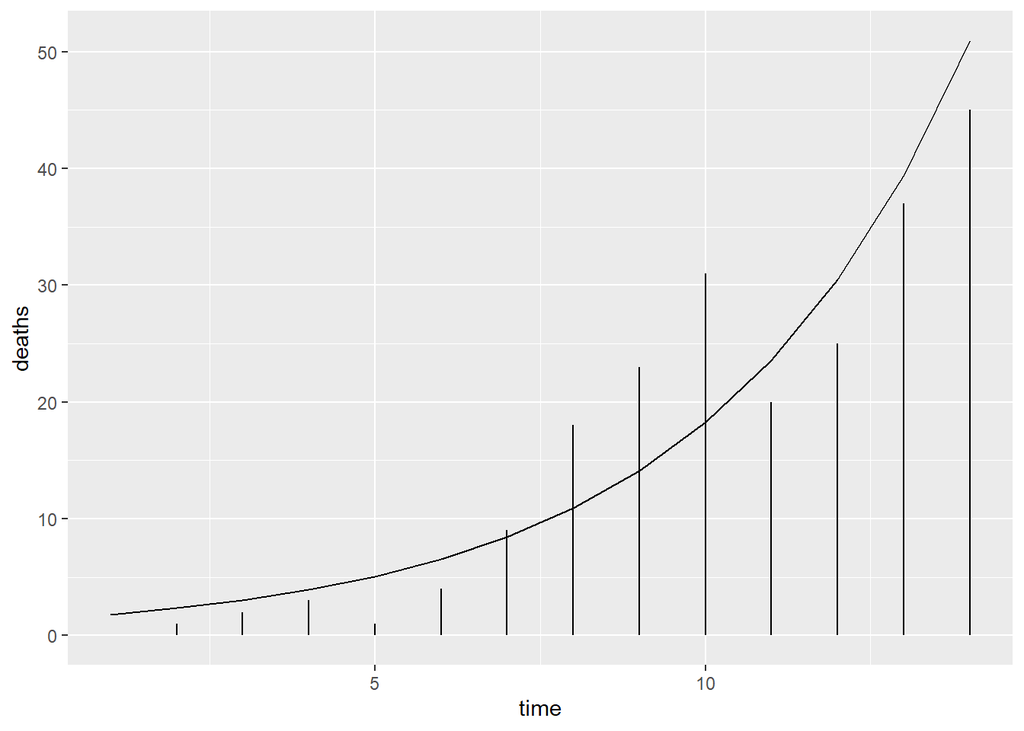

```r
require(ggplot2)
aids$pred <- predict(glm2,type="response")
ggplot(aids,aes(x=time,xend=time,y=0,yend=deaths))+
  geom_segment()+
  geom_line(aes(x=time,y=pred))+
  xlab("time")+
  ylab("deaths")
```

Calculate the predicted number of deaths in month 15:

```r
exp(predict(glm2, newdata=data.frame(time=15)))
```

```
##        1
## 65.85714
```

```r
# or
predict(glm2, newdata=data.frame(time=15), type="response")
```

```
##        1
## 65.85714
```

```r
# or
exp(0.3396+0.2565*15)
```

```
## [1] 65.8316
```

$~$

## Exercise 2 (Leukaemia data: Example 3 from lecture 7)

Read in and display the data

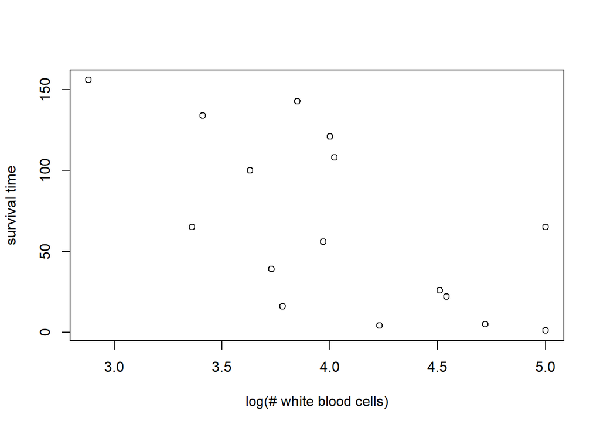

```r
leu <- read.table("https://andygolightly.github.io/teaching/MATH43515/leukaemie.asc", header=TRUE)

plot(leu, xlab="log(# white blood cells)",ylab="survival time")
```

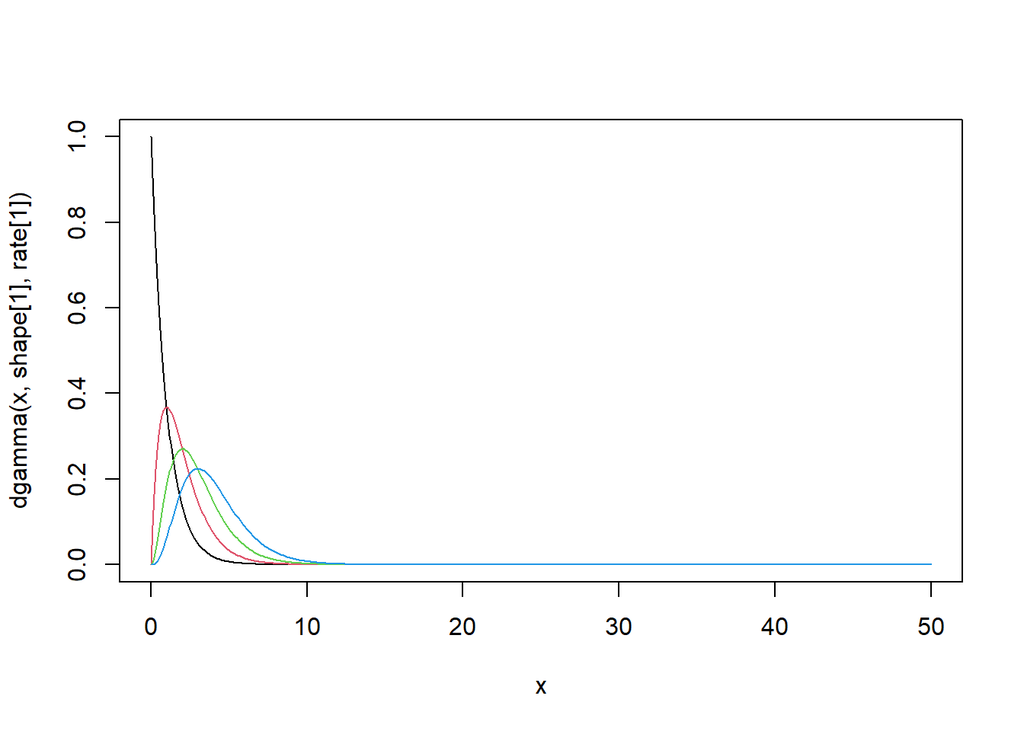

```r
x <- seq(0,50, by=0.1)
shape <- c(1,2,3,4,5)
rate  <- c(1,1,1,1,1)

plot(x, dgamma(x, shape[1], rate[1]), type="l")
for (j in 2:4)
  {
   lines(x, dgamma(x, shape[j], rate[j]), col=j)
  }
```

**TASK:** Fit a generalized linear model with `time` as response, and `wbc` as predictor. Use a `Gamma` response distribution and a log link.

Now plot the fitted response as a function of `wbc` by uncommenting the following code:

```r
# plot(leu, xlab="log(number of white blood cells)",ylab="survival time")
# lines(leu$wbc[order(leu$wbc)], predict(glm3, type="response")[order(leu$wbc)])
```

**TASK:** In the above, why is the use of `order` necessary?

**TASK:** recreate the above plot using `ggplot`.

**TASK:** Predict the survival time for a white blood cell count of 160.

**HARDER:** What does the following code do? (assumes that `glm3` contains the fitted model.)

```r
#out <- predict(glm3,newdata=data.frame(wbc=log(160)), type="link",se.fit=TRUE)
#c(exp(out$fit-2*out$se.fit),exp(out$fit+2*out$se.fit))
```

$~$

## Exercise 2 solutions

Fit a generalized linear model with `time` as response, and `wbc` as predictor. Use a `Gamma` response distribution and a log link:

```r
glm3 <- glm(time ~ wbc, family=Gamma(link=log), data=leu)
summary(glm3)
```

```
##
## Call:
## glm(formula = time ~ wbc, family = Gamma(link = log), data = leu)
##
## Deviance Residuals:
##     Min       1Q   Median       3Q      Max
## -1.9922  -1.2102  -0.2242   0.2102   1.5646
##
## Coefficients:
##             Estimate Std. Error t value Pr(>|t|)
## (Intercept)   8.4775     1.6034   5.287 9.13e-05 ***
## wbc          -1.1093     0.3872  -2.865   0.0118 *
## ---
## Signif. codes:  0 '***' 0.001 '**' 0.01 '*' 0.05 '.' 0.1 ' ' 1
##
## (Dispersion parameter for Gamma family taken to be 0.9388638)
##
##     Null deviance: 26.282  on 16  degrees of freedom
## Residual deviance: 19.457  on 15  degrees of freedom
## AIC: 173.97
##
## Number of Fisher Scoring iterations: 8
```

Now plot the fitted response as a function of `wbc` by uncommenting the following code:

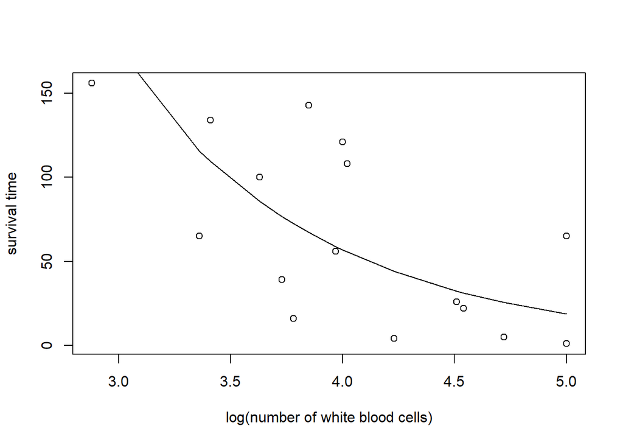

```r
plot(leu, xlab="log(number of white blood cells)",ylab="survival time")
lines(leu$wbc[order(leu$wbc)], predict(glm3,type="response")[order(leu$wbc)])
```

Note that the `lines` function will draw *straight lines* between x values specified by `wbc` and y values specified by the corresponding prediction. Without ordering `wbc` (and the corresponding predictions accordingly), the resulting plot will look rather strange!

Now recreate the plot using `ggplot`:

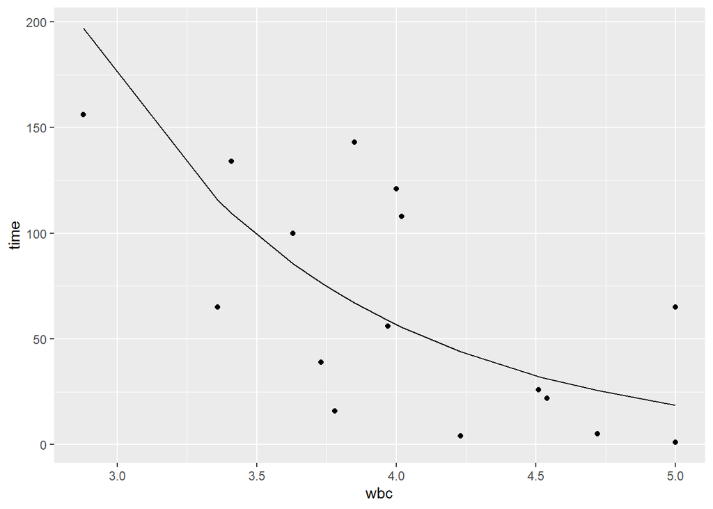

```r
leu$pred <- predict(glm3,type="response")
ggplot(leu,aes(x=wbc,y=time))+
  geom_point()+
  geom_line(aes(x=wbc[order(wbc)],y=pred[order(wbc)]))
```

Predict the survival time for a white blood cell count of 160:

```r
predict(glm3,newdata=data.frame(wbc=log(160)), type="response")
```

```
##        1
## 17.24667
```

The following code produces an approximate 95% confidence interval for the expected survival time given a white blood cell count of 160.

```r
out <- predict(glm3,newdata=data.frame(wbc=log(160)), type="link",se.fit=TRUE)
c(exp(out$fit-2*out$se.fit),exp(out$fit+2*out$se.fit))
```

```
##         1         1
##  7.066335 42.093604
```

Note that we first find an interval for the *linear predictor* and then run this through the *response function* (which is the `exp` function for this example).

**Bonus** - overlay a 95% confidence interval:

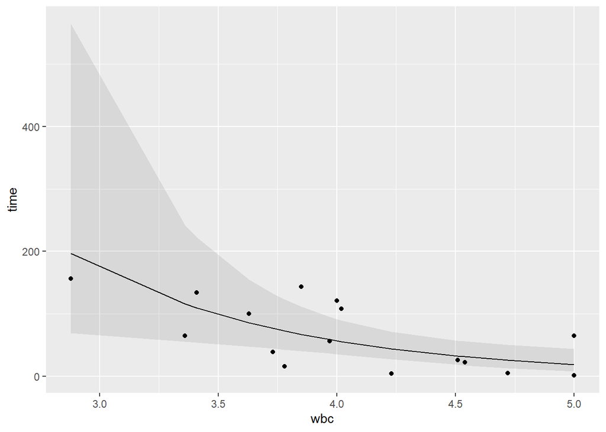

```r
out <- predict(glm3, type="link",se.fit=TRUE)
leu$lower <- exp(out$fit-2*out$se.fit)
leu$upper <- exp(out$fit+2*out$se.fit)
ggplot(leu,aes(x=wbc,y=time))+
  geom_ribbon(aes(ymin = lower, ymax = upper), alpha = 0.1)+
  geom_point()+
  geom_line(aes(x=wbc[order(wbc)],y=pred[order(wbc)]))
```

## Summative assessment

If there is still time remaining, please use this to work on your summative assessment.